# PGS Educational Attainment

# Data Preprocessing

1. First, I wanted to investigate which variables are time dependent and also exclude some that were clearly unnecessary (i.e., “SITE”,“COLPROT”,“ORIGPROT”, “FLDSTRENG”,“FSVERSION”,“IMAGEUID”, “Month_bl”,“Month”,“M”,“update_stamp”).
2. Merge time dependent and independent variables into the long_dat data frame. Also, I recoded the time points in the VISCODE variable into integers.

```r
long_dat <- dat[, c(ivars[,1], nivars[,1])] %>%
  mutate(VISCODE = match(VISCODE, c("bl", "m03", "m06", "m12", "m18", "m24",
                                    "m30","m36", "m42", "m48", "m54", "m60",
                                    "m66", "m72","m78", "m84", "m90", "m96",
                                    "m102", "m108","m114", "m120", "m126",
                                    "m132", "m144", "m156"))-1) %>%
  relocate(RID, PTID, VISCODE) %>%
  arrange(RID, VISCODE)
```

3. In the original data frame there were quite some _bl or _BL variables. Thus, I wanted to check whether these columns had already been integrated or not at each corresponding time point for each participant. Surprise, the test was negative.
4. Therefore, I continued with merging the _bl/_BL variables with the corresponding time dependent variable for each participant. Additionally, I specified the data type of each variable individually for optimal control and oversight over the data structure.
5. Transform Long to Wide Data Format

```
## # A tibble: 6 × 1,153
##   RID   PTID         AGE PTGENDER PTEDUCAT PTETHCAT PTRACCAT PTMARRY APOE4 FDG_0
##   <fct> <chr>      <dbl> <fct>       <int> <fct>    <fct>    <fct>   <int> <dbl>
## 1 2     011_S_0002  74.3 Male           16 Not His… White    Married     0  1.37
## 2 3     011_S_0003  81.3 Male           18 Not His… White    Married     1  1.08
## 3 4     022_S_0004  67.5 Male           10 Hisp/La… White    Married     0 NA
## 4 5     011_S_0005  73.7 Male           16 Not His… White    Married     0  1.29
## 5 6     100_S_0006  80.4 Female         13 Not His… White    Married     0 NA
## 6 7     022_S_0007  75.4 Male           10 Hisp/La… More th… Married     1 NA
## # ℹ 1,143 more variables: FDG_2 <dbl>, FDG_7 <dbl>, FDG_11 <dbl>, FDG_12 <dbl>,
## #   FDG_13 <dbl>, FDG_14 <dbl>, FDG_15 <dbl>, FDG_16 <dbl>, FDG_17 <dbl>,
## #   FDG_18 <dbl>, FDG_19 <dbl>, FDG_21 <dbl>, FDG_22 <dbl>, FDG_23 <dbl>,
## #   FDG_24 <dbl>, FDG_3 <dbl>, FDG_4 <dbl>, FDG_5 <dbl>, FDG_6 <dbl>,
## #   FDG_9 <dbl>, FDG_8 <dbl>, FDG_10 <dbl>, FDG_25 <dbl>, FDG_20 <dbl>,
## #   FDG_1 <dbl>, PIB_0 <dbl>, PIB_2 <dbl>, PIB_7 <dbl>, PIB_11 <dbl>,
## #   PIB_12 <dbl>, PIB_13 <dbl>, PIB_14 <dbl>, PIB_15 <dbl>, PIB_16 <dbl>, …
```

# Age Distribution in Data Frame

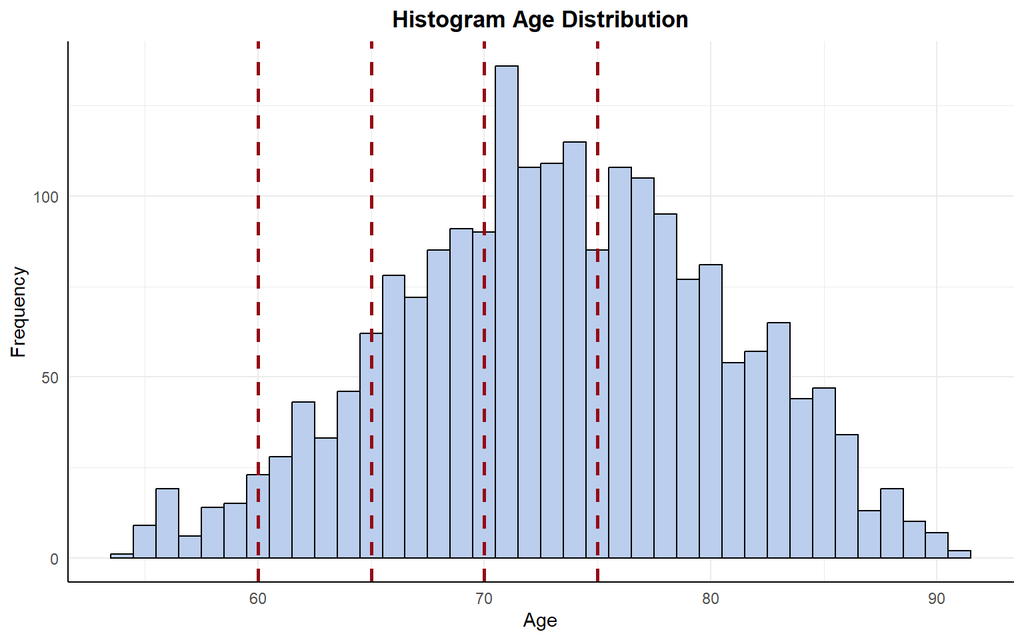

# Attrition Analysis

Based on the number of participants measured at any time point I made a frequency plot to get a first idea of the sampling frequency.

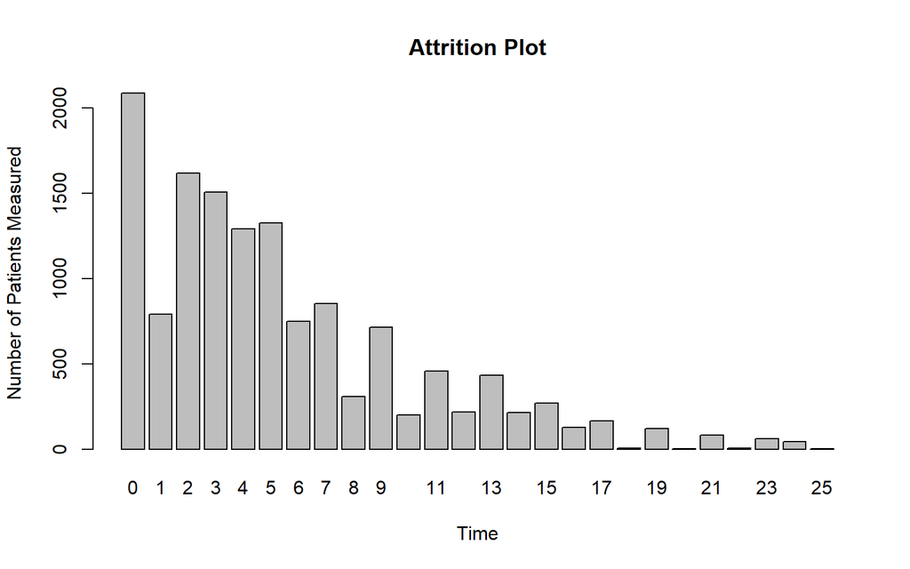

# Domains

## Demographics

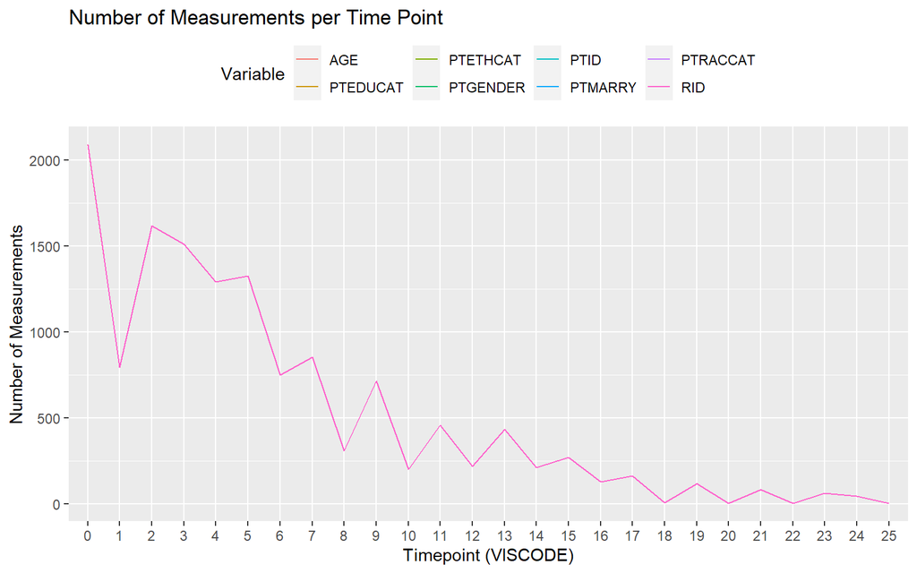

## Cognitive Tests

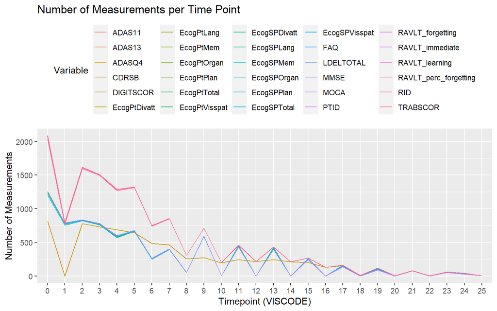

## Biomedical Imaging

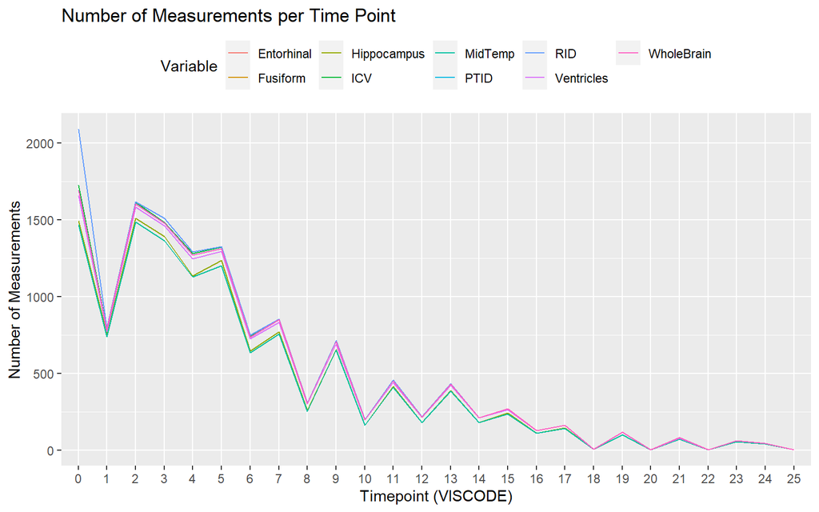

## Biomarkers

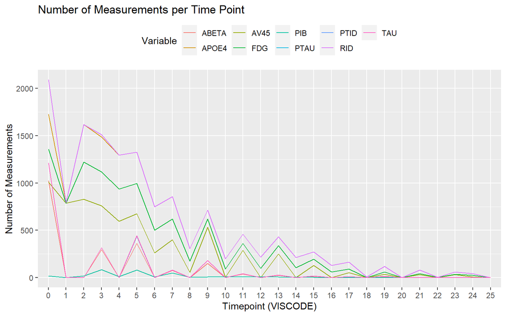

# Polygenic Score for Educational attainment

The merge(by.x, by.y) function creates a new data frame that only keeps those rows for which there is a matching key (in our case PTID). Therefore, we do have genetic data from 2 additional individuals for which we do not have any other measurements. The final data frame for which testing data and genetic data is available is thus, 1408 (N).

## Plot PGS EA vs. Actual EA

Based on this plot, we can see a positive relationship between the polygenic score for education attainment and actual years of education. This means that with a higher PGS score comes higher genetic capacity for educational attainment.

We ran Pearson’s correlation which resulted in r = 0.286 (p-value < 2.2e-16)

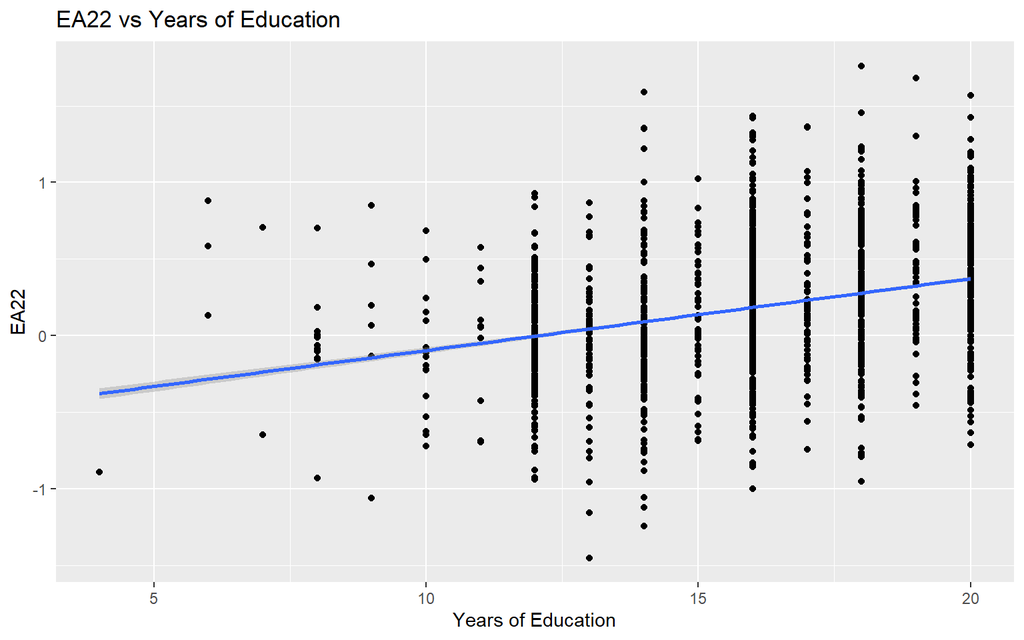

## Check linear regression assumptions

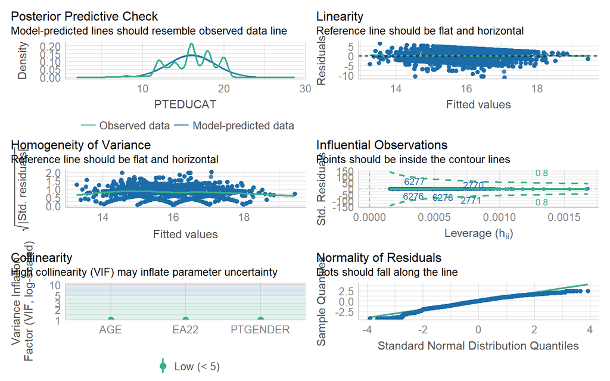

```r
# Linear regression model
model <- lm(PTEDUCAT~EA22+AGE+PTGENDER,data=long_dat)

# Check model assumptions
check_model(model)
```

## Create Residuals

To get the residual we regressed the polygenic risk score for educational attainment against actual EA including the variables SEX & AGE as covariates. The results are depicted in the density plot.

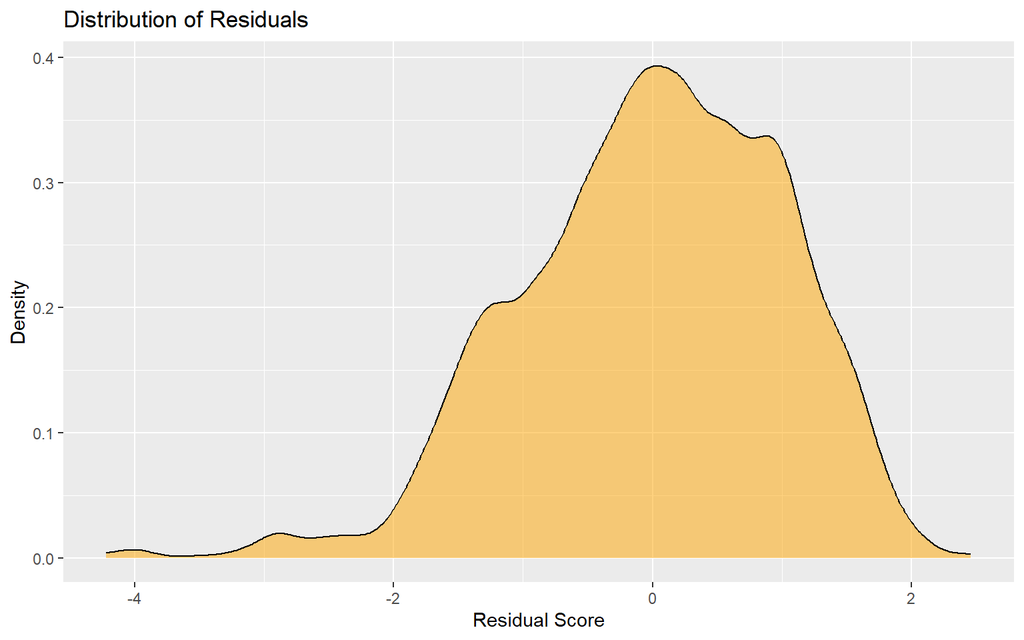

## How to interpret the Residuals?

It is important to correctly interpret the residual scores. The correct way to interpret them is, that a high residual score means that the individual has over-performed relative to his or her genetic capacity. See for example in this table for a short proof:

```
##   Actual Predicted  Residuals
## 1     18  16.91911  1.0808864
## 2     16  15.16815  0.8318481
## 3     12  16.64336 -4.6433625
## 4     20  16.02560  3.9743989
## 5     14  14.83958 -0.8395765
## 6     13  15.37284 -2.3728412
```

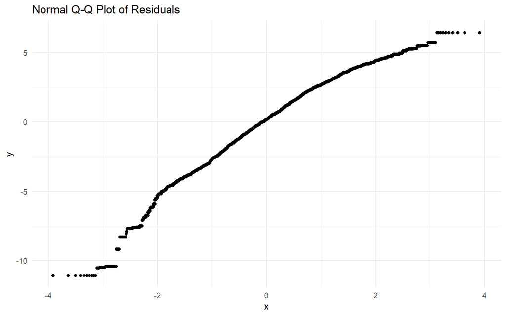

# Survival Analysis

Using the ntile function from dplyr, the lower tertile will be assigned value 1 (~ negative residual), middle tertile value 2 and upper tertile value 3 (~positive residual). The time-point is limited to the 9th follow-up (i.e., 48 months)

## Mini-Mental State Examination (MMSE)

“The mini–mental state examination (MMSE) is a 30-point questionnaire that is used extensively in clinical and research settings to measure cognitive impairment. It is commonly used in medicine and allied health to screen for dementia. It is also used to estimate the severity and progression of cognitive impairment and to follow the course of cognitive changes in an individual over time; thus making it an effective way to document an individual’s response to treatment.Administration of the test takes between 5 and 10 minutes and examines functions including registration (repeating named prompts), attention and calculation, recall, language, ability to follow simple commands and orientation. […] Any score of 24 or more (out of 30) indicates a normal cognition. Below this, scores can indicate severe (≤9 points), moderate (10–18 points) or mild (19-23 points) cognitive impairment.” (Wikipedia.org). The MMSE scores were normalized using the NormPsy package and then the cut-off was calculated.

### Boxplots of MMSE by Age Group at Baseline

To see if it is necessary to stratify for age groups effect of polygenic risk score for EA and age group was tested using linear regression. The results are displayed below.

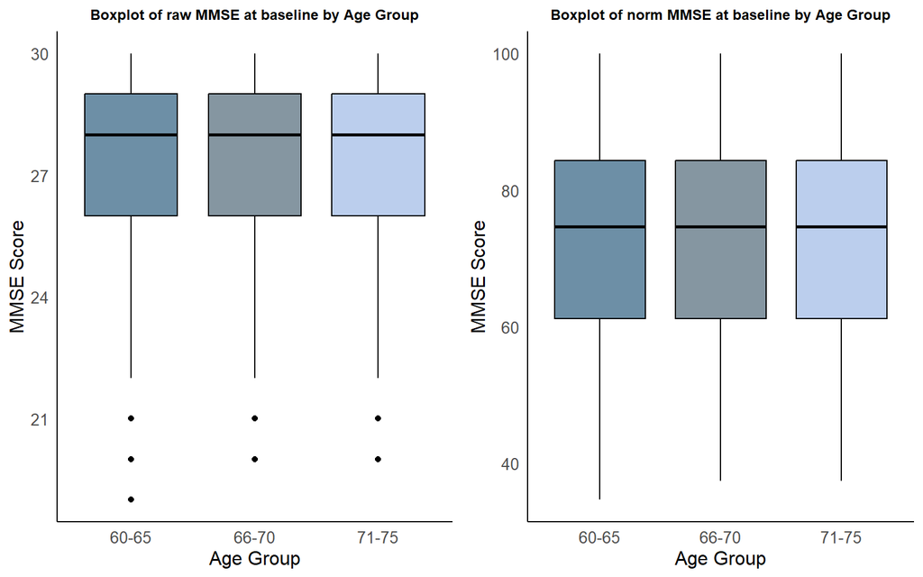

```
##
## Call:
## lm(formula = MMSE ~ EA22 + Age_Group, data = long_dat)
##
## Residuals:
##     Min      1Q  Median      3Q     Max
## -27.415  -1.189   1.109   2.458   3.473
##
## Coefficients:
##             Estimate Std. Error t value Pr(>|t|)
## (Intercept) 27.12540    0.16657 162.844  < 2e-16 ***
## EA22         0.45636    0.11384   4.009 6.19e-05 ***
## Age_Group   -0.01018    0.06723  -0.151     0.88
## ---
## Signif. codes:  0 '***' 0.001 '**' 0.01 '*' 0.05 '.' 0.1 ' ' 1
##
## Residual standard error: 3.642 on 4822 degrees of freedom
##   (6151 observations deleted due to missingness)
## Multiple R-squared:  0.003326,   Adjusted R-squared:  0.002912
## F-statistic: 8.045 on 2 and 4822 DF,  p-value: 0.0003249
```

```
##
## Call:
## lm(formula = MMSE_norm ~ EA22 + Age_Group, data = long_dat)
##
## Residuals:
##     Min      1Q  Median      3Q     Max
## -77.457 -14.481   1.461  21.439  29.791
##
## Coefficients:
##             Estimate Std. Error t value Pr(>|t|)
## (Intercept)  75.4231     0.9389  80.330  < 2e-16 ***
## EA22          3.7284     0.6416   5.811 6.62e-09 ***
## Age_Group    -0.1925     0.3790  -0.508    0.611
## ---
## Signif. codes:  0 '***' 0.001 '**' 0.01 '*' 0.05 '.' 0.1 ' ' 1
##
## Residual standard error: 20.53 on 4822 degrees of freedom
##   (6151 observations deleted due to missingness)
## Multiple R-squared:  0.006955,   Adjusted R-squared:  0.006543
## F-statistic: 16.89 on 2 and 4822 DF,  p-value: 4.923e-08
```

### MMSE Survival Analysis

Next the survival analysis was conducted for the genetic capacity of educational attainment and the residual educational attainment.

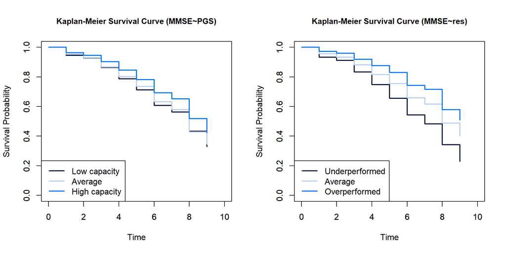

The difference between the high and low capacity/residual Educational attainment are 3.354398^{-5} and 4.5572169^{-23} respectively. In the next step the survival analysis was conducted stratified for genetic capacity for educational attainment.

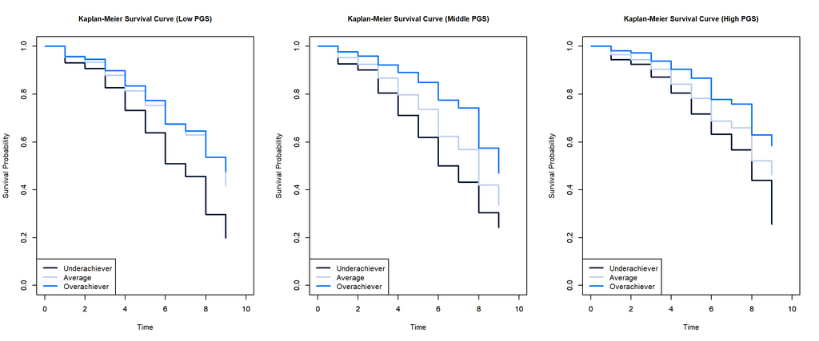

Log Test Low: 7.2954207^{-10}  
Log Test Middle: 1.5611391^{-16}  
Log Test High:3.2760959^{-5}

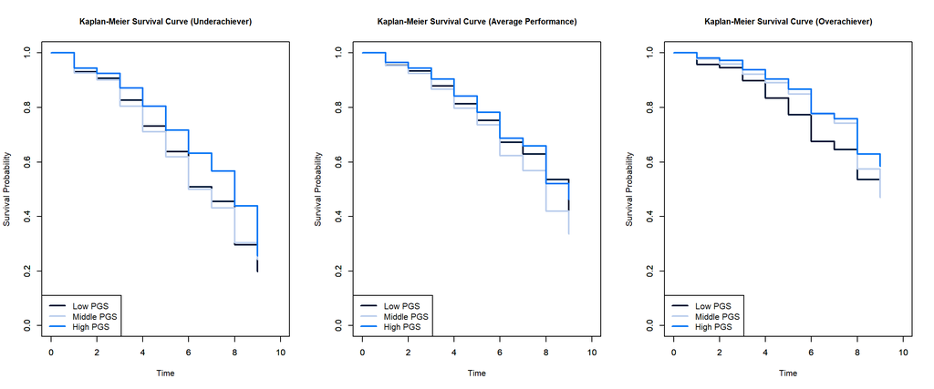

Log Test Underachiever: 4.6115298^{-6}  
Log Test Average Performance: 0.9924534  
Log Test Overachiever:0.0145068

## Alzheimer’s Disease Assessment Scale

The Cognitive Subscale Alzheimer’s Disease Assessment Scale (ADAS) is made of 11 tasks that include both subject-completed tests and observer-based assessments, assessing the memory, language, and praxis domains. The result is a global final score ranging from 0 to 70, based on the sum of the scores of the single tasks (ADAS11).

Beyond the ADAS11 score, the ADNI study included also an additional test of delayed word recall and a number cancellation or maze task, which are further summed to have a new total score that ranges from 0 to 85 (ADAS13).

In addition, the score of the task 4 (Word Recognition, ADASQ4) was included in the ADNIMERGE dataset.

([Grassi et al., 2019](https://www.ncbi.nlm.nih.gov/pmc/articles/PMC6646724/))

### ADAS11

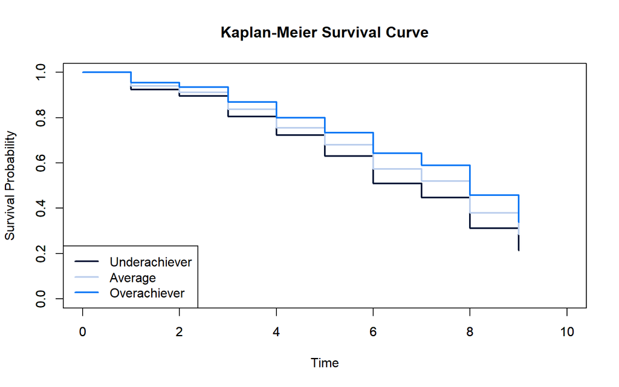

```
## Call:
## survdiff(formula = Surv(as.integer(VISCODE), ADAS11_cut) ~ thirtile_res,
##     data = .)
##
## n=5540, 5 observations deleted due to missingness.
##
##                   N Observed Expected (O-E)^2/E (O-E)^2/V
## thirtile_res=1 2799     1198     1008      36.0      81.7
## thirtile_res=3 2741      800      990      36.6      81.7
##
##  Chisq= 81.7  on 1 degrees of freedom, p= <2e-16
```

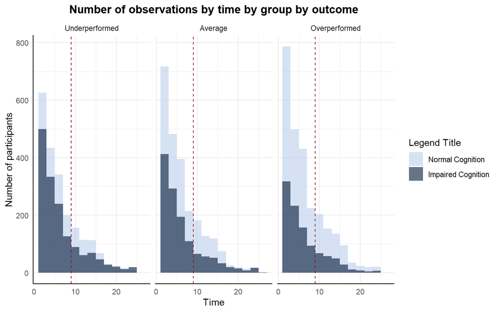

### ADAS13

“The ADAS13 was included as a global measure of cognitive function. ADAS13 is a test battery developed to assess severity of cognitive impairment associated with AD and includes subtests and clinical evaluations assessing memory function, reasoning, language function, orientation and praxis. The ADAS13 is a modified version of the original ADAS-Cog-11, adding a cancellation task and a delayed free recall task. The higher the scores, the more severe impairment of cognitive function.” (Mofrad et al., 2021)

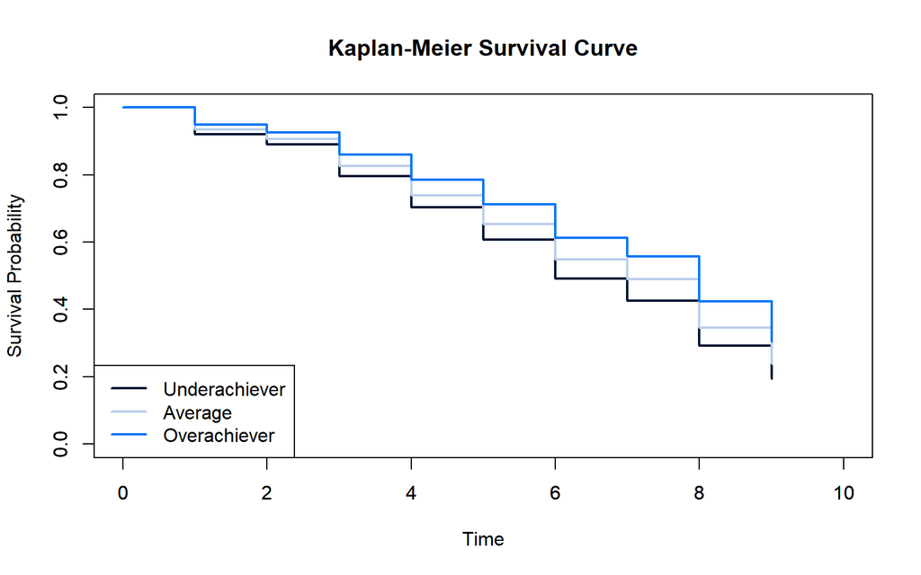

```
## Call:
## survdiff(formula = Surv(as.integer(VISCODE), ADAS13_cut) ~ thirtile_res,
##     data = .)
##
## n=7290, 27 observations deleted due to missingness.
##
##                   N Observed Expected (O-E)^2/E (O-E)^2/V
## thirtile_res=1 3649     1619     1354      51.8       111
## thirtile_res=3 3641     1095     1360      51.6       111
##
##  Chisq= 111  on 1 degrees of freedom, p= <2e-16
```

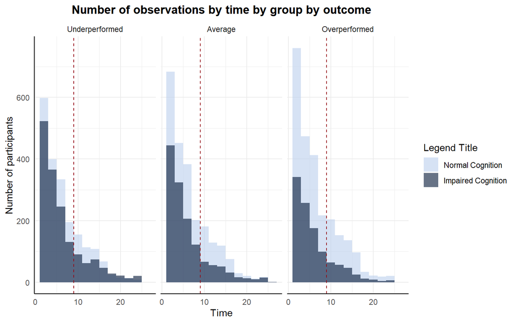

### ADASQ4

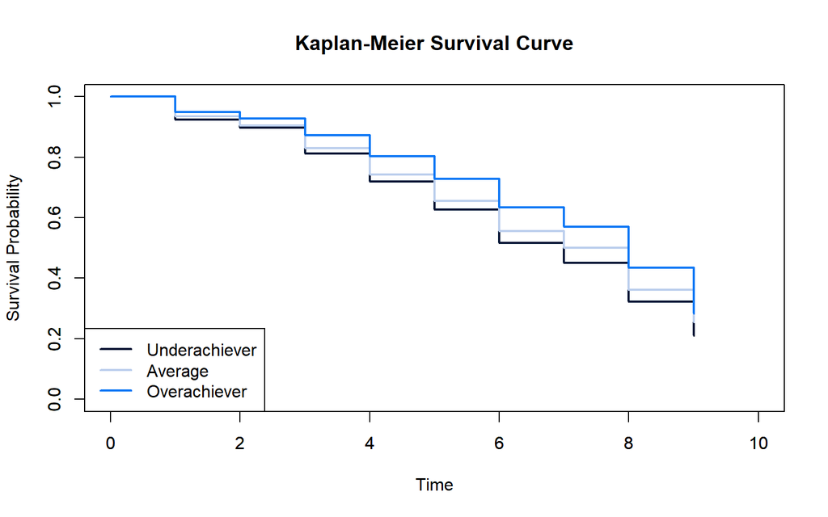

```
## Call:
## survdiff(formula = Surv(as.integer(VISCODE), ADASQ4_cut) ~ thirtile_res,
##     data = .)
##
##                   N Observed Expected (O-E)^2/E (O-E)^2/V
## thirtile_res=1 3659     1492     1273      37.8      80.2
## thirtile_res=3 3658     1067     1286      37.4      80.2
##
##  Chisq= 80.2  on 1 degrees of freedom, p= <2e-16
```

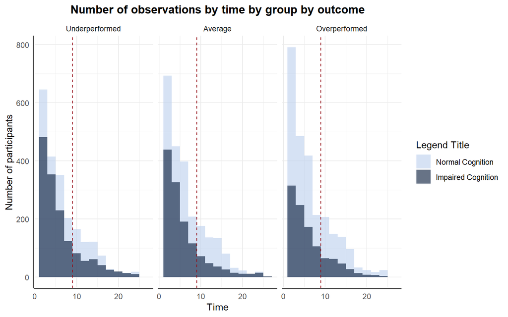

## CDRSB

“The clinical dementia rating (CDR) scale is commonly used to diagnose dementia due to Alzheimer’s disease (AD). The sum of boxes of the CDR (CDR-SB) has recently been emphasized and applied to interventional trials for tracing the progression of cognitive impairment (CI) in the early stages of AD.” ([Tzeng et al., 2022](https://www.ncbi.nlm.nih.gov/pmc/articles/PMC9537043/))

See [Table 3](https://www.ncbi.nlm.nih.gov/pmc/articles/PMC3409562/table/T3/?report=objectonly) for explanation on the staging category ([O’Bryant et al., 2012](https://www.ncbi.nlm.nih.gov/pmc/articles/PMC3409562/))

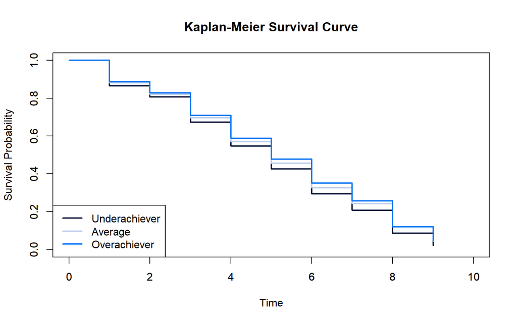

```
## Call:
## survdiff(formula = Surv(as.integer(VISCODE), CDRSB_cut) ~ thirtile_res,
##     data = .)
##
##                   N Observed Expected (O-E)^2/E (O-E)^2/V
## thirtile_res=1 3659     2779     2566      17.6      39.8
## thirtile_res=3 3658     2384     2597      17.4      39.8
##
##  Chisq= 39.8  on 1 degrees of freedom, p= 3e-10
```

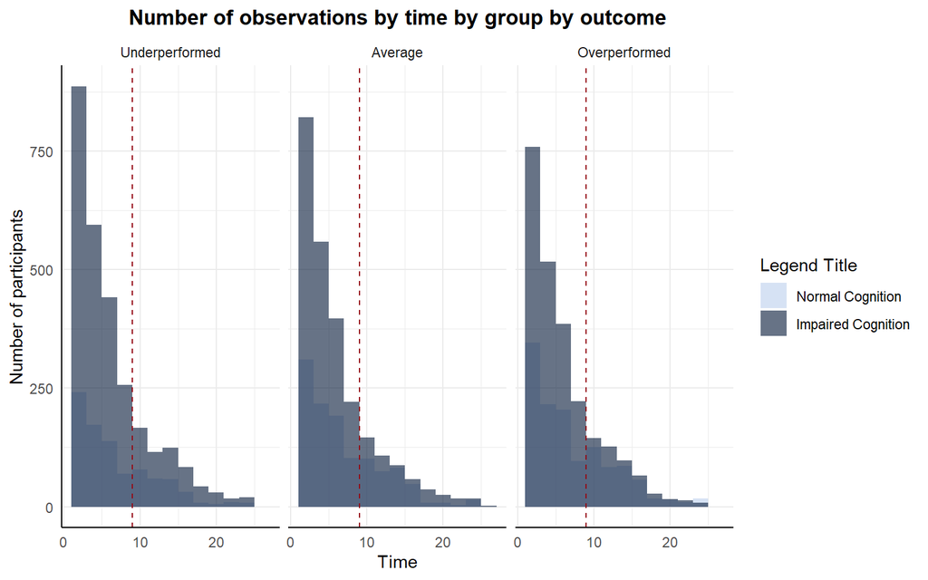

## DIGITSCORE

“The DSST (Digit Symbol Substitution Test) is a paper-and-pencil cognitive test presented on a single sheet of paper that requires a subject to match symbols to numbers according to a key located on the top of the page. The subject copies the symbol into spaces below a row of numbers. The number of correct symbols within the allowed time, usually 90 to 120 seconds, constitutes the score.” ([Jaeger, 2018](https://www.ncbi.nlm.nih.gov/pmc/articles/PMC6291255/)) The lower the scores, the more severe impairment of cognitive function.

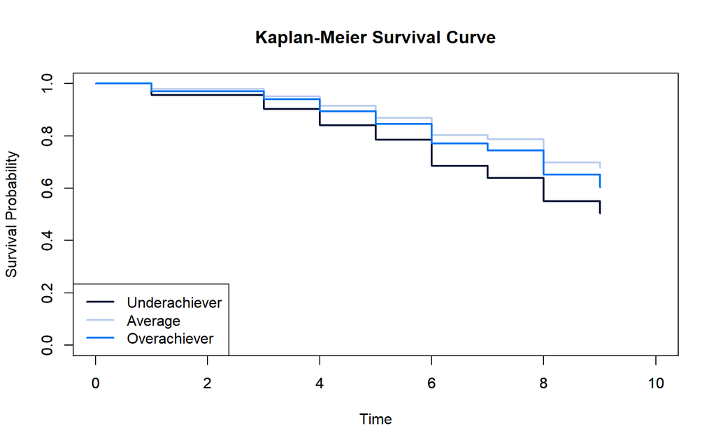

```
## Call:
## survdiff(formula = Surv(as.integer(VISCODE), DIGITSCOR_cut) ~
##     thirtile_res, data = .)
##
## n=4029, 3288 observations deleted due to missingness.
##
##                   N Observed Expected (O-E)^2/E (O-E)^2/V
## thirtile_res=1 2146      455      367      20.9        45
## thirtile_res=3 1883      251      339      22.7        45
##
##  Chisq= 45  on 1 degrees of freedom, p= 2e-11
```

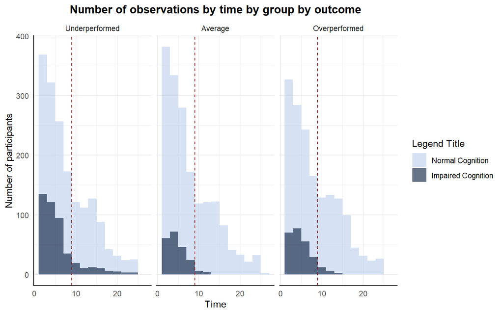

## FAQ

The Functional Activities Questionnaire is used to assess an individual’s functional abilities in daily living activities. It is a caregiver-based questionnaire that helps evaluate how well a person is able to perform various instrumental activities of daily living (IADLs) and basic activities of daily living (ADLs). (ChatGPT) Sum scores (range 0-30). The score range for each item is 0–3 (higher scores indicate greater impairment; 0 = normal or never did but could do now; 1 = has difficulty but does by self or never did but would have difficulty now; 2 = requires assistance; 3 = dependent). There is no established cut-off score for IADL impairment on the FAQ. However, one study reported that a total FAQ score (sum of all 10 item scores; range 0–30) of ≥ 6 is suggestive of functional impairment [ [20](https://pubmed.ncbi.nlm.nih.gov/15592138/)]. ([Marshall et al., 2015](https://www.ncbi.nlm.nih.gov/pmc/articles/PMC4448081/))

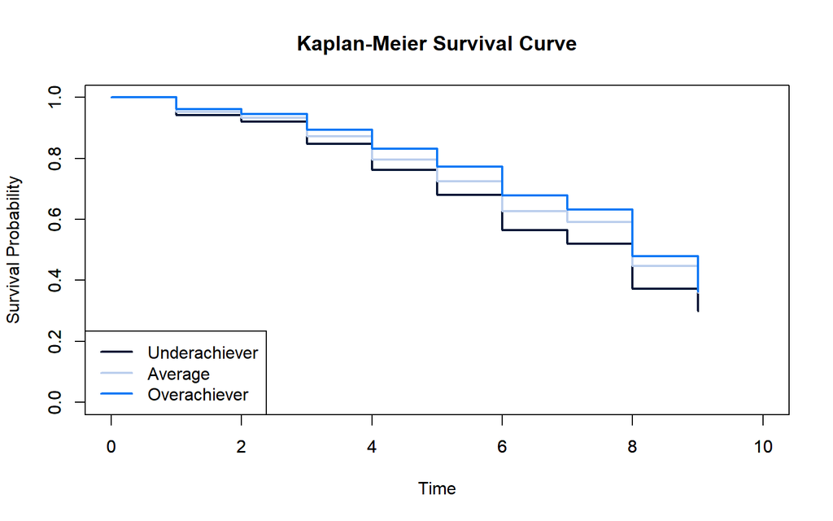

```
## Call:
## survdiff(formula = Surv(as.integer(VISCODE), FAQ_cut) ~ thirtile_res,
##     data = .)
##
## n=7308, 9 observations deleted due to missingness.
##
##                   N Observed Expected (O-E)^2/E (O-E)^2/V
## thirtile_res=1 3659     1281     1090      33.5      70.9
## thirtile_res=3 3649      908     1099      33.2      70.9
##
##  Chisq= 70.9  on 1 degrees of freedom, p= <2e-16
```

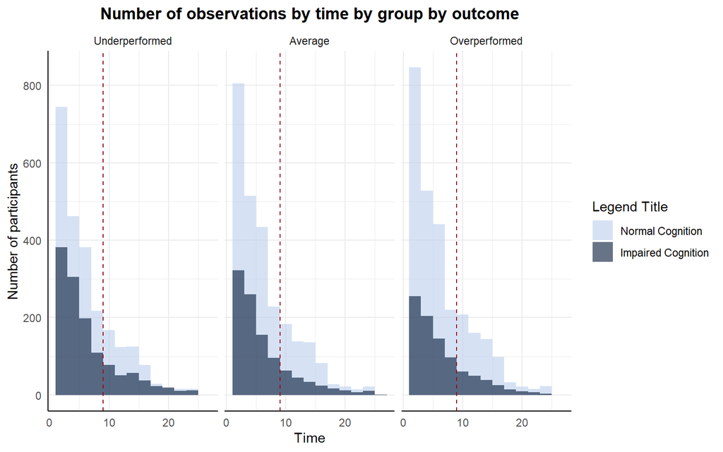

## LDELTOTAL

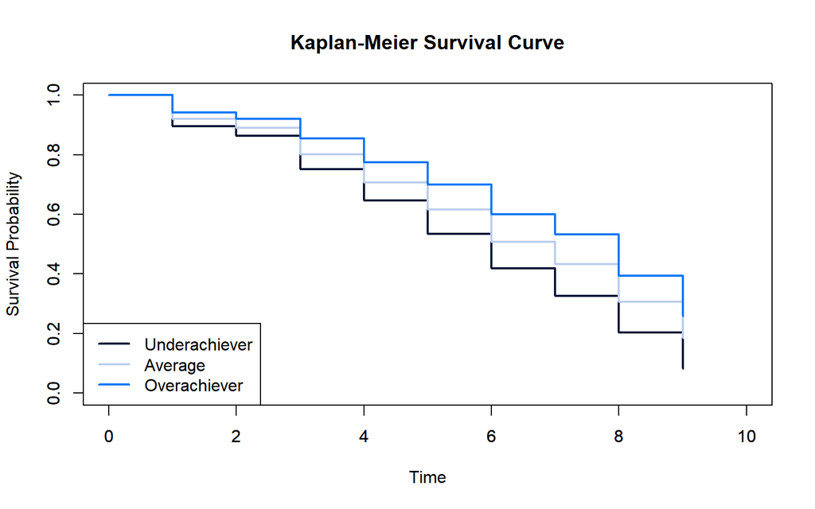

```
## Call:
## survdiff(formula = Surv(as.integer(VISCODE), LDELTOTAL_cut) ~
##     thirtile_res, data = .)
##
##                   N Observed Expected (O-E)^2/E (O-E)^2/V
## thirtile_res=1 3659     2017     1587       117       251
## thirtile_res=3 3658     1174     1604       115       251
##
##  Chisq= 251  on 1 degrees of freedom, p= <2e-16
```

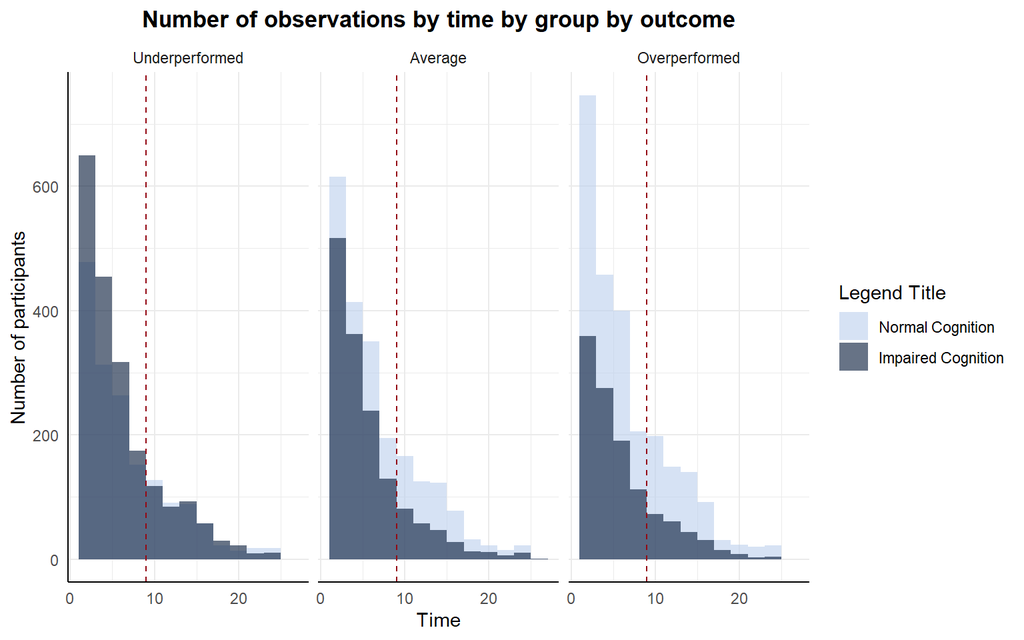

## MOCA

Reference literature: doi: 10.1111/j.1532-5415.2005.53221.x

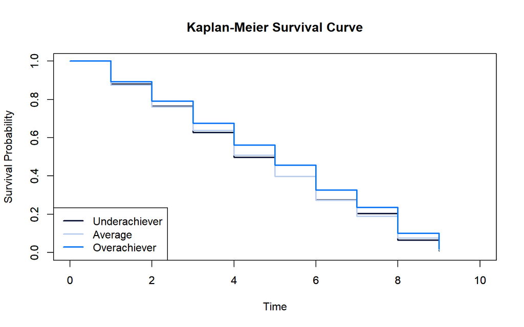

```
## Call:
## survdiff(formula = Surv(as.integer(VISCODE), MOCA_cut) ~ thirtile_res,
##     data = .)
##
## n=3896, 3421 observations deleted due to missingness.
##
##                   N Observed Expected (O-E)^2/E (O-E)^2/V
## thirtile_res=1 1819     1348     1277      3.97      8.91
## thirtile_res=3 2077     1310     1381      3.67      8.91
##
##  Chisq= 8.9  on 1 degrees of freedom, p= 0.003
```

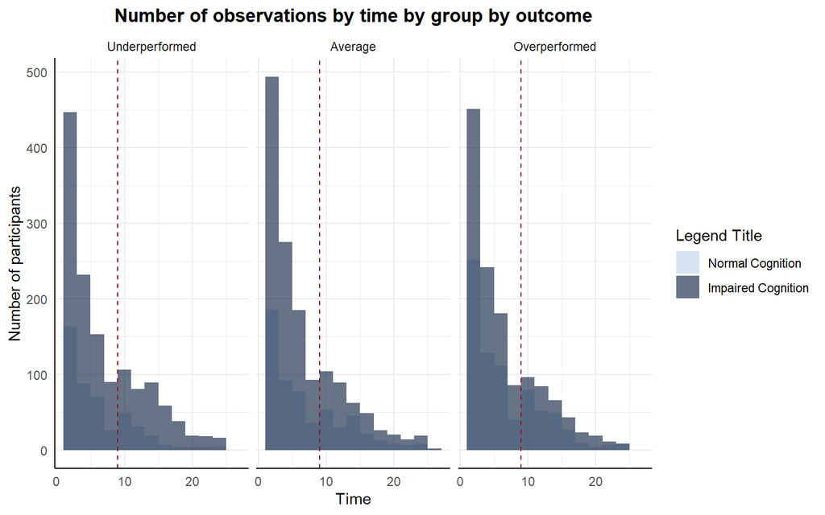

## Rey-Auditory Verbal Learning Test (RAVLT)

The RAVLT was included as a measure of memory function. In this test, the participants are asked to recall words from a list of 15 nouns immediately after each of five learning trials and after a short and a long delay. Two measures known to be sensitive to cognitive changes in patients with AD were included in the present study: Immediate recall (RAVLT-Im): the number of correct responses across the immediate recall of the five learning trials; percent forgetting (RAVLT-PF): the score on the fifth learning trial minus the score on the long delayed recall, divided by the score obtained on the fifth learning trial. The lower the scores, the more severe impairment of cognitive function.

### RAVLT Immediate

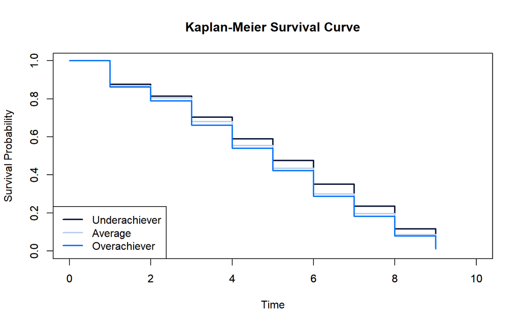

```
## Call:
## survdiff(formula = Surv(as.integer(VISCODE), RAVLT_immediate_cut) ~
##     thirtile_res, data = .)
##
## n=7299, 18 observations deleted due to missingness.
##
##                   N Observed Expected (O-E)^2/E (O-E)^2/V
## thirtile_res=1 3651     2612     2796      12.1      27.9
## thirtile_res=3 3648     3006     2822      12.0      27.9
##
##  Chisq= 27.9  on 1 degrees of freedom, p= 1e-07
```

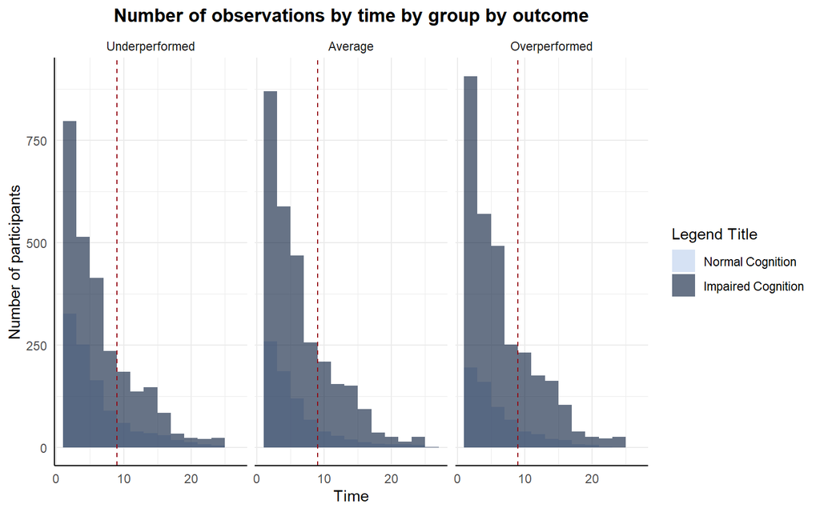